# SLR FINAL EXAM

### DATA DESCRIPTION:

The data set consists of complete educational details of students right from their schooling to MBA and previous work experience. Our main objective is to predict the Salary of the students based on the info available. The data set consists of 391 observations and 19 variables.

### ATTRIBUTES:

SlNo - ID of the student

Gender - Gender of Student

Percent_SSC - Percentage of marks scored in SSC

Board_SSC - Types of Boards in SSC

Percent_HSC - Percentage of marks scored in HSC

Board_HSC - Types of Boards in HSC

Stream_HSC - Specialization in HSC

Percent Degree - Percentage of marks scored in Degree

Course_Degree - Different courses in degree

Experience_Yrs - Work Experience of the Students

Entrance_Test - Test which students give for MBA college Entrance

Percentile_ET - Percentage of marks scored in Entrance_Test

Percent_MBA - Percentage of marks scored in MBA

Specialization_MBA - Specialization in MBA

Marks Communication - Percentage of marks scored in Communication

Marks_Projectwork - Percentage of marks scored in Project Work

Marks_BOCA - Percentage of marks scored by students in Extra Curricular

activities

Placement - Whether Student got placed or not

Salary - Salary of students

### 1. Read the dataset (tab, csv, xls, txt, inbuilt dataset)

## Kindly change the below cells from markdown to code and execute it

import pandas as pd

import csv

with open("data_set.csv","r")as file:

```
reader=csv.reader(file)
```

df=pd.read_csv("data_set.csv")

df.head()

```python
import pandas as pd
import matplotlib.pyplot as plt
import seaborn as sns
from scipy import stats
import numpy as np
```

```python
df=pd.read_excel('Admission.xlsx')
df.head()
```

|  | SlNo | Gender | Percent_SSC | Board_SSC | Percent_HSC | Board_HSC | Stream_HSC | Percent_Degree | Course_Degree | Experience_Yrs | Entrance_Test | Percentile_ET | Percent_MBA | Specialization_MBA | Marks_Communication | Marks_Projectwork | Marks_BOCA | Placement | Salary |
| --- | --- | --- | --- | --- | --- | --- | --- | --- | --- | --- | --- | --- | --- | --- | --- | --- | --- | --- | --- |
| 0 | 1 | M | 62.00 | Others | 88.00 | Others | Commerce | 52.00 | Science | 0 | MAT | 55.0 | 58.80 | Marketing & HR | 50 | 65 | 74 | Placed | 270000 |
| 1 | 2 | M | 76.33 | ICSE | 75.33 | Others | Science | 75.48 | Computer Applications | 1 | MAT | 86.5 | 66.28 | Marketing & Finance | 69 | 70 | 75 | Placed | 200000 |
| 2 | 3 | M | 72.00 | Others | 78.00 | Others | Commerce | 66.63 | Engineering | 0 | NaN | 0.0 | 52.91 | Marketing & Finance | 50 | 61 | 59 | Placed | 240000 |
| 3 | 4 | M | 60.00 | CBSE | 63.00 | CBSE | Arts | 58.00 | Management | 0 | MAT | 75.0 | 57.80 | Marketing & Finance | 54 | 66 | 62 | Placed | 250000 |
| 4 | 5 | M | 61.00 | CBSE | 55.00 | ISC | Science | 54.00 | Engineering | 1 | MAT | 66.0 | 59.43 | Marketing & HR | 52 | 65 | 67 | Placed | 180000 |

### 2. Summarize important observations from the data set (5 Marks)

Some pointers which would help you, but don’t be limited by these

a. What are the number of rows; no. & types of variables (continuous, categorical etc.)

b. Calculate five point summary for numerical variables

c. Summarize observations for categorical variables – no. of categories, % observations in each category

```python
df.shape
```

```
(391, 19)
```

```python
df.describe()
```

|  | SlNo | Percent_SSC | Percent_HSC | Percent_Degree | Experience_Yrs | Percentile_ET | Percent_MBA | Marks_Communication | Marks_Projectwork | Marks_BOCA | Salary |
| --- | --- | --- | --- | --- | --- | --- | --- | --- | --- | --- | --- |
| count | 391.000000 | 391.000000 | 391.000000 | 391.000000 | 391.000000 | 391.000000 | 391.000000 | 391.000000 | 391.000000 | 391.000000 | 391.000000 |
| mean | 196.000000 | 64.652353 | 63.795294 | 62.983606 | 0.478261 | 54.934962 | 61.667698 | 60.539642 | 68.363171 | 64.378517 | 219078.260870 |
| std | 113.016223 | 10.960426 | 11.417726 | 8.916152 | 0.667112 | 31.168264 | 5.854399 | 8.824084 | 7.145095 | 9.582834 | 138311.647036 |
| min | 1.000000 | 37.000000 | 40.000000 | 35.000000 | 0.000000 | 0.000000 | 50.830000 | 50.000000 | 50.000000 | 50.000000 | 0.000000 |
| 25% | 98.500000 | 56.000000 | 54.000000 | 57.525000 | 0.000000 | 41.190000 | 57.195000 | 53.000000 | 64.000000 | 57.000000 | 172800.000000 |
| 50% | 196.000000 | 64.500000 | 63.000000 | 63.000000 | 0.000000 | 62.000000 | 61.010000 | 58.000000 | 69.000000 | 63.000000 | 240000.000000 |
| 75% | 293.500000 | 74.000000 | 72.000000 | 69.000000 | 1.000000 | 78.000000 | 66.020000 | 67.000000 | 74.000000 | 72.500000 | 300000.000000 |
| max | 391.000000 | 87.200000 | 94.700000 | 89.000000 | 3.000000 | 98.690000 | 77.890000 | 88.000000 | 87.000000 | 96.000000 | 940000.000000 |

```python
df.dtypes
```

```
SlNo                     int64
Gender                  object
Percent_SSC            float64
Board_SSC               object
Percent_HSC            float64
Board_HSC               object
Stream_HSC              object
Percent_Degree         float64
Course_Degree           object
Experience_Yrs           int64
Entrance_Test           object
Percentile_ET          float64
Percent_MBA            float64
Specialization_MBA      object
Marks_Communication      int64
Marks_Projectwork        int64
Marks_BOCA               int64
Placement               object
Salary                   int64
dtype: object
```

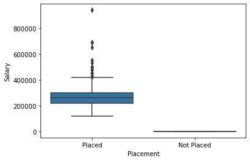

```python
sns.boxplot(df['Placement'],df['Salary'])
plt.show()
```

### 3. Check for defects in the data. Perform necessary actions to ‘fix’ these defects (5 Marks)

Some pointers which would help you, but don’t be limited by these

a. Do variables have missing/null values?

b. Do variables have outliers?

c. Is the data normally distributed? Is it a defect? Why or why not?

```python
df.isnull().sum()
```

```
SlNo                    0
Gender                  0
Percent_SSC             0
Board_SSC               0
Percent_HSC             0
Board_HSC               0
Stream_HSC              0
Percent_Degree          0
Course_Degree           0
Experience_Yrs          0
Entrance_Test          67
Percentile_ET           0
Percent_MBA             0
Specialization_MBA      0
Marks_Communication     0
Marks_Projectwork       0
Marks_BOCA              0
Placement               0
Salary                  0
dtype: int64
```

```python
z = np.abs(stats.zscore(df.select_dtypes(include=['float64','int64'])))
threshold = 3
print(np.where(z > 3))
```

```
(array([ 17, 110, 171, 202, 204, 244, 256, 258, 293, 303, 317, 371, 379],
      dtype=int64), array([ 3,  7,  9, 10,  4,  4,  4, 10, 10, 10,  3,  4,  7], dtype=int64))
```

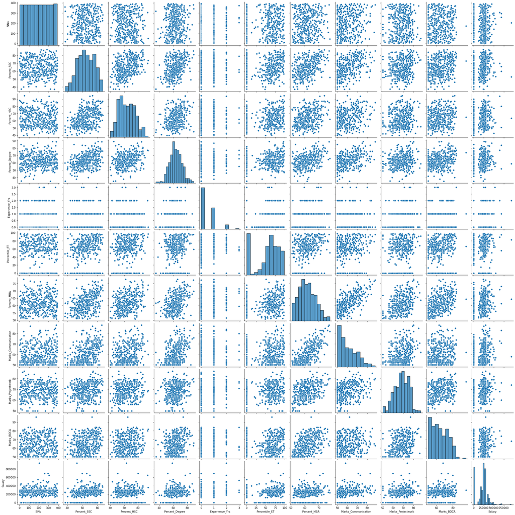

```python
sns.pairplot(df)
plt.show()
```

### 4. Summarize relationships among variables (10 marks)

a. Plot correlation plots. Which are the variables most correlated with Target? Which independent variables are correlated among themselves? Do you want to exclude some variables from the model based on this analysis? What other actions will you take?

b. Plot all independent variables with the target. Are all relationships linear? If not, what steps would you take based on this information?

Hint: based on your observations you may want to transform features or create additional features.

### 5. Split dataset into train and test (70:30) (5 marks)

a. Are both train and test representative of the overall data? How would you ascertain this statistically?

### 6. Fit a base model. Please write your key observations (15 marks)

a. What is the overall R2? Please comment on whether it is good or not.

b. What is the adjusted R2? Is it different from R2? Why?

c. Which variables are significant?

d. Is there multicollinearity?

e. Which other key model output parameters do you want to look at?

### 7. How do you improve the accuracy of the model? Write clearly the changes that you will make before re-fitting the model. Fit the final model. (20 marks)

Please feel free to have any number of iterations to get to the final answer. Marks are awarded based on the quality of final model you are able to achieve.

### 8. Summarize as follows (10 marks)

1. Summarize the overall fit of the model and list down the measures to prove that it is a good model
2. Write down a business interpretation/explanation of the model – which variables are affecting the target the most and explain the relationship. Feel free to use charts or graphs to explain.
3. What changes from the base model had the most affect on model performance
4. What are the key risks to your results and interpretation